# Data exploration strategies using R

Week 2

#### Outline of the session

This week we are going to make a start on data visualisation and exploration. To do this we will use graphical techniques that visualize and transform to explore data in a systematic way, a task that statisticians call **exploratory data analysis**, or EDA for short. EDA is an iterative cycle, where you:

- Generate questions about your data.
- Search for answers by visualizing, transforming, and modelling your data.

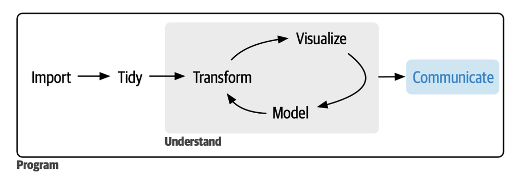

**Figure 1:** The data analysis cycle.

This is long process so we will start with the basics which we will extend and reinforce in the coming workshops. Today we going to use the dataset you created at the end of the last workshop, supplemented by some data that are available in the base R. The aim is to use the ggplot2 package to do this work and we will use a range of different types of graphs to illustrate how to represent data structure and the relationship between columns of data in our dataframes. We will introduce you to base R graphics as the workshops progress.

Data exploration is an important and integral part of data analysis. If you read around this you will find that people suggest it is appropriate to spend ~ 50% of your analytical time engaged in exploring your datasets to identify (sometimes hidden) issues. This is key to highlighting:

1. The variation and in the data. Or, put another way, the distribution of the data.
2. Possible typological / recording issues in the data.
3. The presence of influential and extreme points - sometimes termed ‘outliers’.

Statisticians (and all researchers by association if they use statistics) use visualization and transformation to explore their data in a systematic way. Statisticians call this exploratory data analysis, or EDA for short. EDA is an iterative cycle where you:

- Generate questions about your data.
- Search for answers by visualizing, transforming, and modelling your data.
- Use what you learn to refine your questions and/or generate new questions.

***Session Aim** To understand the importance of data visualisation for data analysis.

**Learning Outcomes** At the end of this workshop your will be able to use the **ggplot2** package for data visualisation with a range of types of graphics to examine your data in terms of:

- Comparisons of variables
- Examining data distributions and frequencies
- Finding associations between variables
- Identifying potential outliers
- Creating high quality graphics

**Maxim of the day “Don’t start data analysis without exploring the data (graphically) first”**

#### An introduction to ggplot2 (from the tidyverse package)

We are going to use **ggplot2** for all our plotting in this module unless it is more difficult to do so (i.e. GIS type functions). As I mentioned R was created to generate excellent graphic so the functions in base R to this are extensive. My decision to use **ggplot2** is base on its clear graphical structure or as Wickham et al. might say, **its grammar of graphics**. There is a whole book dedicated to this:

Wickham, H., Gentleman, R., Hornick, K. & Parmigiani, G. (2009) *ggplot2: Elegant Graphics for Data Analysis*. Springer. New York.

The third updated edition is freely available here should you wish to read it: https://ggplot2-book.org/

It works by layering up components as shown below in Figure 2. This is a screenshot from Wickham et al. (2024) i.e. the book list in the URL above. The text describes the elements better than I could.

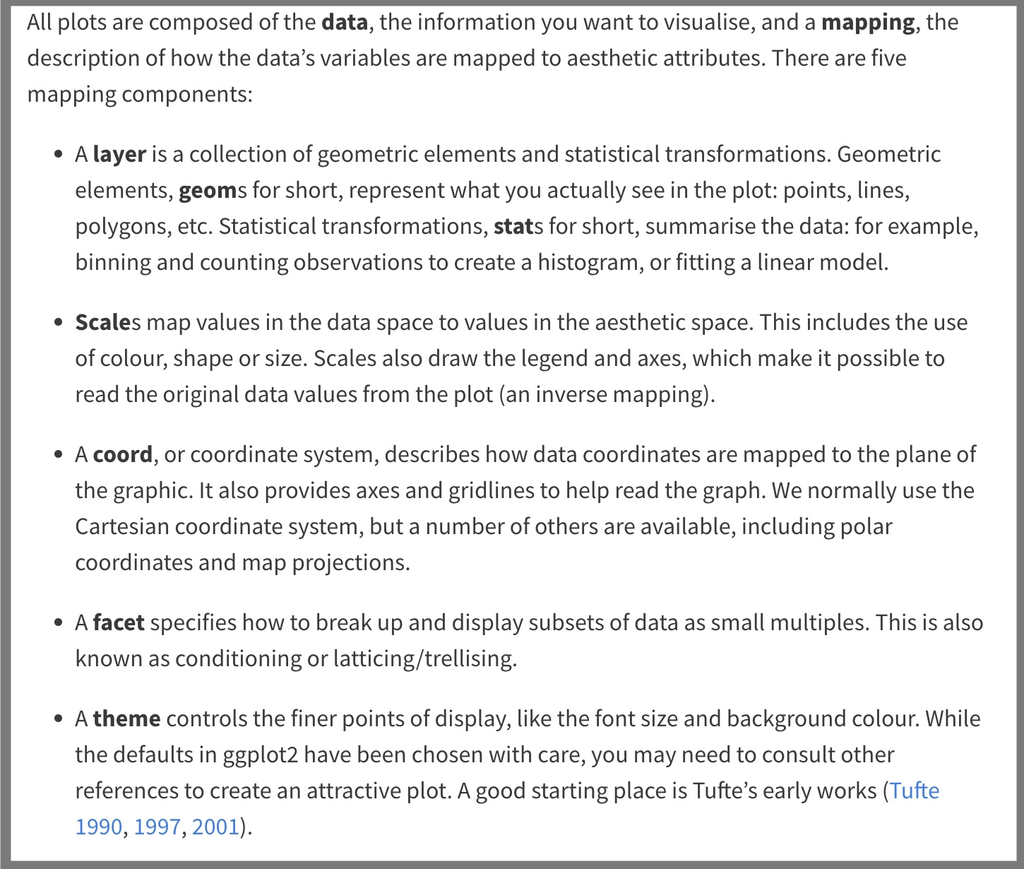

**Figure 2:** ggplot2 core structural elements.

**Do not stress if this all appears impenetrable. We will unpack it in today’s workshop and reinforce your understanding in subsequent sessions as the module progresses**. Let’s make a start on today’s activities.

#### Things to do at the start of each session

1. **Set your working directory**. Note RStudio can save your working environment so you may already have that in hand from the last session i.e. the WD might be correct. If not either set it manually by clicking on the **Session** option from the top bar, click on **Set Working Directory** then **Choose Directory** and use the search window to click through to your directory and select **Open**. Alternatively, you can type in the address of the working directory manually using the setwd() function as demonstrated below. This requires you to type in the full address of where your data are stored. **Pay attention to the double quotes around the path address**.
2. **Load the packages** that you want to use. In this session we only need the **tidyverse** package. We’ll be installing many more as the sessions progress so the list will increase in size.

```r
library("tidyverse") # don't forget to use the quote marks!
```

3. Find the dataset from last week. Recall it was named “practical_data.csv”. When you saved it, the file would have been put in the work directory which was live at that point. So depending on how you organised things, it’ll likely be in directory called ‘Week 1’ or something similar. To keep things tidy I tend to organise my file structure in a manner that separates codefiles from the datafiles. I put all my codefiles in directory called ‘Codefiles’ and all my datafiles in a directory called ‘Data’. I also have subdirectories for ‘Docs’, ‘Images’ and ‘Outputs’ To load the data in, I code that directly using the **setwd()** function. Figure 3 (below) shows a screenshot of this structure. **You need to figure out a strategy that works for you**.

[figure not shown]

**Figure 3:** Jon’s directory structure.

4. **Create your new script by new file clicking on the green cross at the top left of the window -> selecting ‘Script file’ from the dropdown list.** A new file called **untitled** will be added to the tabs. Click on the tab and then blue disk icon to save the file. Note that it will be saved to your current working directory, so make sure you are happy with that location. Give it a name that is meaningful to you. I name mine with module code and then week number (e.g. LM40222_LSOA_Week_1.Rmd). Note that I use R notebooks to create the html documents for these classes so the file extension (or suffix if you like) is **Rmd**. You are creating scripts so their extension will be **.R**.

#### Today’s session

Let’s starting by loading at your dataset. Mine is now located in my data directory -> in the Birmingham Census 2021 MSOA subdirectory. I am going to load it directly from there using the appropriate path. It’s long so I am setting my WD to there manually as described above, copying the path using **getwd()** and adding the path and filename to my **read_csv()** function call:

```r
BhamData <- read_csv("/Users/jonsadler/Documents/GitHub/Teaching/LM_40222_Quantitative_Methods/Data/Birmingham Census 2021 MSOA/practical_data.csv") # notice the use of quotes.
```

When loaded it will appear in the “Environment” window (top right). I called it “BhamData”. Let’s revise how it is structured. This time we’ll use **glimpse()** rather than **str**. But why not run them both and compare the differences.

I called the imported data **BhamData** you can call it whatever you want but as we progress remember where my code states **BhamData** you need to replace it with **your dataframe name** if you called it something else! We need to revisit the structure of the data before we start plotting things.

```r
glimpse((BhamData))
```

- Code - the unique LSOA codes.
- White_British which is the % of people who are white and British.
- Low_Occupancy which is % of people living in very overcrowded accommodation where there are not enough bedrooms that meet statuory guidance.
- Unemployed which is the % of people of working (that aren’t students) who are unemployed.
- Qualification which is % of people with higher level qualifications (i.e. effectively post school qualifications).

We can also see that the data type are double (i.e. decimal numbers) as shown by adjacent to column 2,3,4, and 5, but column 1 (i.e. **Code**) is shown as meaning it is a character data class. R will use this a **factor** in our analyses for many statistical functions but not all, so we need to remember that! Recall also that the data we are using are all percentages so we don’t want to see any numbers larger than 100! We can check by using the **summary()** function.

```r
summary(BhamData)
```

#### Data Visualisation - Creating your first ggplot

We are going to start by walking you through the steps to create an image. It will be a complex journey but you don’t have to understand everything to start with. **Don’t panic**. What we are doing is replicating Chapter 1 in https://r4ds.hadley.nz/data-visualize called **Data Visualisation** but using our data. **The plot below is our ultimate goal**.

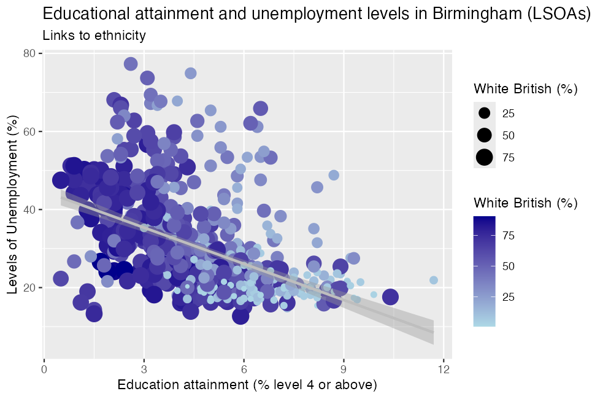

We’ll recreate this plot step-by-step. To begin with we use the function **ggplot()**, defining a plot object that you then add layers to. The first argument of ggplot() is the dataset to use in the graph and so we add data=BhamData in into the bracket in the function call: **ggplot(data = BhamData)**. This creates our blank canvas which we layer things onto.

```r
ggplot(data = BhamData) # when run it we get a grey box in plot window (bottom left)
```

Next up we add in the mapping argument of the **ggplot()** function. This defines which variable in our dataset we are to map and also to visual properties (**aesthetics**) of your plot. The mapping argument uses **aes()** function, and the x and y arguments of **aes()** tell ggplot which variables to map to the x and y axes. To start with we go for using % with higher level qualifications X axis and the % of people Unemployed on Y. Notice that we opt for % Unemployed on Y as we might reasonably expect unemployments to be linked to qualifications. What we are saying here is the % of people Unemployed is a likely **response** which is **dependent** on qualification levels. We call the X axis variable either an **independent** or **explanatory** variable. I prefer using response and explanatory because it makes more sense to me but you can go with whatever works for you, with one stipulation: **The Y axis variable should always be your response or dependent variable**.

```r
ggplot(
  data = BhamData,
  mapping = aes(x = Qualification, y = Unemployed))
```

We add the data by selecting a **geom** or the geometrical object that a plot uses to represent data. All geometric objects in ggplot2 start with **geom**. People often describe plots by the type of geom that the plot uses. For example, bar charts use bar geoms **geom_bar()**, line charts use line geoms **geom_line()**, boxplots use boxplot geoms **geom_boxplot()**, scatterplots use point geoms **geom_point()**, and so on. Because we are displaying two variables as an XY plot we use will use **geom_point()**. **Notice to add this we put a** +** sign at the end of the last line in the code which tells ggplot another command is coming, them we add the new command, in this case **geom_point**. It this way we build up layers on the graphics canvas.

```r
ggplot(
  data = BhamData,
  mapping = aes(x = Qualification, y = Unemployed)) + geom_point()
```